# Targeted Methylation Results

Project: Differential Gene Expression and Pulmonary Function in Vaping LatinX Adolescents Analyst: Trent Hawkins Investigator(s): Sunita Sharma, MD Report generated: April 24, 2023

# Introduction

The purpose of this report is to discover differential methylation among the subset of CpG sites targeted by the genes found to be differentially expressed in the report “teen_vape_DE_report_*yyyy_mm_dd*”. Since this may be considered an *exploratory analysis*, a seperate targeted analysis which includes only genes annotated to some pertinent Gene Ontologies will be presented also. Due to the limited sample size, these targeted analyses were chosen to increase statistical power by limiting the effects of multiple testing.

# Methods

In order to create a targeted subset of CpG Sites, we first mapped CpG sites to their respective genes. This task was accomplished using annotation for Illumina’s EPIC methylation arrays<sup>1</sup>. After which, a subset of CpG Sites was selected based upon the 7,136 genes found to be significantly associated with whether the subject had vaped in the last six months in a previous analysis (FDR < 0.05). Finally, we repeated the False Discovery Rate (FDR) p-value adjustment for multiple testing using the bacon-corrected p-values presented in the previous EWAS report (“DMP_Results_*yyyy_mm_dd*”).

To focus the analysis further, we conducted another targeted analysis which included only the CpG sites which were annotated to the genes found in the Gene Ontologies<sup>3</sup> named “inflammatory response”, “immune system process”, “immune response”, and “cilium”. This search also included CpG sites annotated to the gene “AHRR”, which has been the subject of tobacco-related research<sup>4</sup>. We again repeated the FDR p-value adjustment for only the CpG sites associated with these genes.

# Results

Results are presented below for both the *full* targeted methylation analysis and the *restricted* targeted analysis. The *full* targeted analysis included all CpG sites which mapped to differentially expressed genes from previous analyses. The *restricted* analysis was limited to CpG sites which mapped only to those genes included in Gene Ontologies “inflammatory response”, “immune system process”, “immune response”, and “cilium” in addition to those which mapped to the gene “AHRR”.

## Full Targeted Analysis

7,136 differentially expressed genes mapped to 181,704 unique CpG sites. After subsetting those sites from the full EWAS, only one was significantly differentially methylated using a type-I error rate of 0.05. Increasing the allowed type-I error rate to 0.1 allowed for one additional site. At a type-I error rate of 0.2, there were 27 differentially methylated positions. Those 27 positions mapped to 26 unique genes. Table 1 gives the top 10 sorted by FDR adjusted p-value.

Table 1: Top 10 Targeted CpG Sites by p-value

| CpG | Associated Gene Name | Estimate (M) | Std. Error | t value | p-value | FDR | Associated Gene Reg. |
| --- | --- | --- | --- | --- | --- | --- | --- |
| cg02123174 | REXO1 | −0.346 | 0.066 | −5.220 | < 0.001 | 0.010 | + |
| cg11903190 | CERK | 0.254 | 0.056 | 4.530 | < 0.001 | 0.057 | + |
| cg11171825 | PEX6 | −0.485 | 0.114 | −4.246 | < 0.001 | 0.156 | - |
| cg05241917 | ACE2 | −0.459 | 0.108 | −4.244 | < 0.001 | 0.156 | - |
| cg16232530 | C7orf50 | −0.418 | 0.097 | −4.318 | < 0.001 | 0.156 | - |
| cg06790566 | CDH22 | −0.361 | 0.081 | −4.442 | < 0.001 | 0.156 | - |
| cg04587192 | SRGAP3 | −0.326 | 0.075 | −4.339 | < 0.001 | 0.156 | - |
| cg23918706 | ZC2HC1C | 0.148 | 0.035 | 4.210 | < 0.001 | 0.156 | - |
| cg23918706 | ACYP1 | 0.148 | 0.035 | 4.210 | < 0.001 | 0.156 | - |
| cg15994418 | RAB35 | 0.183 | 0.047 | 3.924 | < 0.001 | 0.156 | + |

Overall, there was only one CpG site in the targeted analysis that may be considered significantly differentially expressed at a type-I error rate of 0.05. That site is cg02123174 and it maps to the gene REXO1 using Illumina’s EPIC annotation. In the context of this analysis, the site is *less* methylated in vapers compared to non-vapers. This result is consistent with RNASeq results where the gene was found to be up-regulated (0.396, p = 0.02). One additional site, cg11903190 may be considered marginally significant at an FDR-adjusted p-value of 0.06. That position maps to the gene CERK. That gene was also found to be up-regulated in RNASeq results (0.395, p = 0.00). **Figure 1** displays boxplots of the estimated relative methylation comparing vapers to non-vapers.

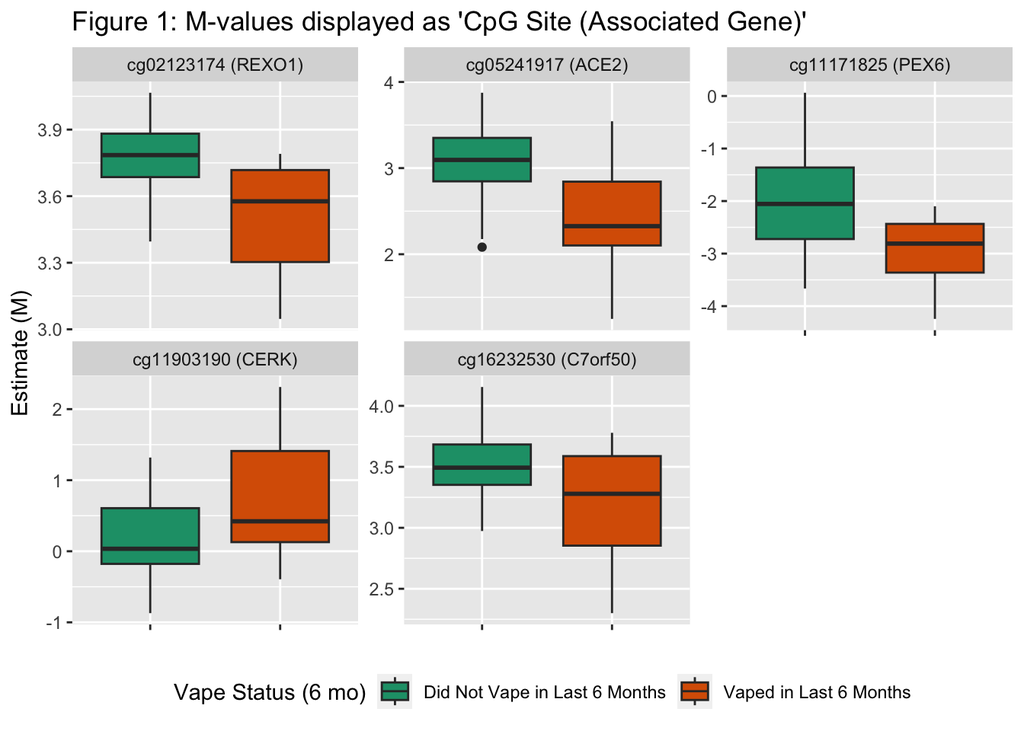

## Restricted Targeted Analysis

There were 90 differentially expressed genes found in the Gene Ontologies “inflammatory response”, “immune system process”, “immune response”, and “cilium”. Those 90 genes and “AHRR” mapped to 2247 unique CpG sites. After correcting those subsetted sites using FDR, 0 sites were found to be differentially methylated at a type-I error rate of 0.2. Figure 2 shows boxplots of relative methylation among the two loci associated with the gene ‘AHRR’ which have been previously shown to serve as biomarkers for tobacco smoke exposure<sup>4</sup>.

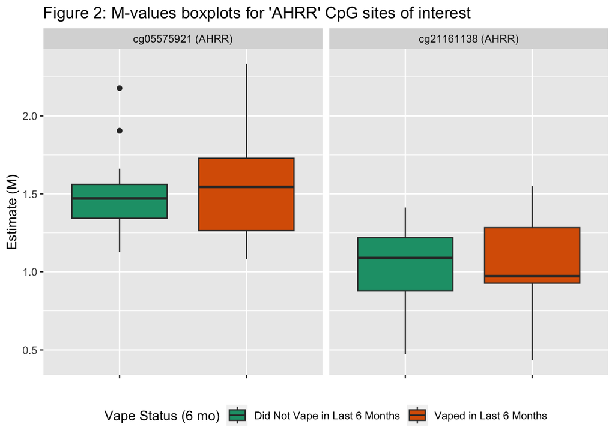

**Figure 2** shows little noticeable difference in methylation at the sites cg05575921 or cg21161138.

# Conclusions

In the case of this analysis, the full targeted analysis showed a limited number of methylation loci that displayed differential methylation between vapers and non-vapers. The relevance of these sites to the mechanisms behind vaping are yet to be determined. Limiting the targeted analysis only to the sites associated with relevant Gene Ontologies as determined by the principal investigators revealed no additional differential methylation patterns between vapers and non-vapers. The next analysis will examine the epigenome for differentially methylated regions, which will further reduce the burden of multiple testing and highlight methylation patterns among vapers and non-vapers.

# References

1.

Hansen KD. *IlluminaHumanMethylationEPICanno.ilm10b4.hg19: Annotation for Illumina’s EPIC Methylation Arrays*.; 2017. https://bitbucket.com/kasperdanielhansen/Illumina_EPIC.

2.

Dolinski K, Dwight S, Eppig J, et al. Gene ontology: Tool for the unification of biology. The gene ontology consortium. *Nat Genet*. 2000;25(1):2529Attri.

3.

The gene ontology resource: Enriching a GOld mine. *Nucleic acids research*. 2021;49(D1):D325-D334.

4.

Richmond RC, Sillero-Rejon C, Khouja JN, et al. Investigating the DNA methylation profile of e-cigarette use. *Clinical Epigenetics*. 2021;13:1-13.